# Statistical Inference with Simple Linear Regression in R

1. Introduction to Statistical Inference for Simple Linear Regression.
2. Perform a t-test on the slope parameter.
3. Estimate variability of the error term.
4. Perform an F-test of Model Fit
5. Perform Confidene and Prediction Intervals

# Introduction to Simple Linear Regression.

**The Basics:**

- A similar linear gression can be obtained from a set of paired data (x, y) using this formula $$\hat\mu_{y|x}=\hat\beta_0+\hat\beta_1x$$.
- The issue though is determining if the point estimates (the parameters for the slope, intercept and error) are useful.
- This post will discuss the inference test that can be performe on simple linear regression and determine if:
  $$H_0\colon y=\beta_0+\varepsilon\quad\text{against}\quad H_a\colon y=\beta_0+\beta_1x+\varepsilon$$
- The null hypothesis suggest that x does not belong to the linear model, and we are looking for evidene to prove that it does, and we specifically test this hypohtesis with this expression:
  $$H_0\colon\beta_1=0\quad\text{against}\quad H_a\colon\beta_1\ne0$$.
- To this this last hypothesis we would need:
  - A point estimate for $\beta_1$
  - The standard error of the point estimate $\widehat{\mathsf{SE}}_{\hat\beta_1}$
  - The degrees of freedom associated with the standard error.
  - Confirmation that the sampling distribution for the $\hat \beta_1$ is approximately normals
- We can then use the t-statistic $$t=\frac{\hat\beta_1-\beta_1}{\widehat{\mathsf{SE}}_{\hat\beta_1}}$$
- The post will use R to demonstrate how to perform the calculations needed to test for inference on a simple linear model.
- The R library MASS will be used, specifically the dataset Rubber to demonstrate such calcuation. The rubber dataset compares the tire rubber loss (grams) bsed on the tensile and hardness properties.

# Perform a t-test on the slope parameter.

**The Basics:**

- Hypothesis test:
  - $$H_0\colon\beta_1=0\quad\text{against}\quad H_a\colon\beta_1\ne0,$$
- Hypothesis test values:
  - Parameter of interest. $\beta_1$
  - Point estimate. $$\hat\beta_1=\frac{SS_{xy}}{SS_{xx}}$$
  - Standard error under $H_0$: $$\widehat{\mathsf{SE}}=\frac{\hat\sigma}{\sqrt{SS_{xx}}}$$
  - Test statistic. $$t=\frac{\hat\beta_1-0}{\widehat{\mathsf{SE}}}$$
  - Null distribution: student's t distribution
  - Degrees of freedom: $$df=n-2$$
  - The residualstandard error, variance: $$\sigma=\sqrt(MSE)$$
- Confidence intervals: You can perform a one-sided test but that isn't common, so it wont be presented here.
  - Calculated as $100(1- \alpha)$
  - Two-sides: $$\hat\beta_1\pm t_{df,\alpha/2}\cdot\widehat{\mathsf{SE}}_{\hat\beta_1}$$
- The following code will demonstrate these principles and calculations using R programming.

## Load Data

```r
library('MASS')
attach(Rubber)
str(Rubber)
```

```
'data.frame':	30 obs. of  3 variables:
 $ loss: int  372 206 175 154 136 112 55 45 221 166 ...
 $ hard: int  45 55 61 66 71 71 81 86 53 60 ...
 $ tens: int  162 233 232 231 231 237 224 219 203 189 ...
```

# Perform Linear Regression Model

```r
loss.lm <- lm(loss~hard)
coefficients(loss.lm)
```

**(Intercept)**

550.415129151291

**hard**

-5.33655307141306

# Obtain a summary that provides key information

- Statistics on the set of residuals, $\epsilon_j = y_j−\hat{y_𝑗}$
- The point estimates, the standard error, the associated t-statistic, and associated p-value (for a two-tailed t-test) associated with both model parameters $\beta_0$ and $\beta_1$ (labeled hard in this example for the explanatory variable)
- The residual standard error, $\hat \sigma = \sqrt{MSE} = 60.52$ with degrees of freedom = n - 2 = 28 in this example
- a Multiple R-squared, which is our coefficient of determination which is our coefficient of determination 0.5442 and is interpreted as the proportion of the observed variability in the response (y) variable that can be explained by the presence of the explanatory variable (x) in the model.

```r
summary(loss.lm)
```

```
Call:
lm(formula = loss ~ hard)

Residuals:
   Min     1Q Median     3Q    Max
-86.15 -46.77 -19.49  54.27 111.49

Coefficients:
            Estimate Std. Error t value Pr(>|t|)
(Intercept) 550.4151    65.7867   8.367 4.22e-09 ***
hard         -5.3366     0.9229  -5.782 3.29e-06 ***
---
Signif. codes:  0 ‘***’ 0.001 ‘**’ 0.01 ‘*’ 0.05 ‘.’ 0.1 ‘ ’ 1

Residual standard error: 60.52 on 28 degrees of freedom
Multiple R-squared:  0.5442,	Adjusted R-squared:  0.5279
F-statistic: 33.43 on 1 and 28 DF,  p-value: 3.294e-06
```

# Verify the standard error of $\hat \beta_1$

- Which should be the same value reported in the std. error column for the slope (explanatory variable row header)

```r
SS.xx <- sum( (hard-mean(hard))^2 )
sigma.hat <- 60.52 # the residual standard error reported from the summary
SE.b1.hat <- sigma.hat/sqrt(SS.xx) ; SE.b1.hat
```

0.922935656843799

# Verify the test statistic t

- This should be the the t-value in the hard header row in the summary table

```r
b1.hat <- -5.3366
t <- b1.hat/SE.b1.hat; t
```

-5.78220156565387

# Verify the p-value with two tailed test

- Since the p-value is less than the level of significance, we can rejec the Null hypothesis in favor for the alternative hypothesis that $\beta_1 \neq 0$

```r
p.value <- 2*pt(t, df=28); p.value
```

3.29364393664094e-06

# Calculate the 95% confidence interval on the slope $\beta_1$

- Confidence interval suggest that a single unit increase in the rubber hardness will decrease the abrasion loss anywhere between 3.44 and 7.22 grams per hours

```r
t.crit <- qt(0.025, 28, lower.tail=FALSE) # t-value for the confidence interval
b1.hat + c(-1,1)*t.crit*SE.b1.hat
```

1. -7.22714799089632

2. -3.44605200910368

# Calculate confidence interval using R method `confint( loss.lm, level=confidence interval as decima )` default is .95

```r
confint( loss.lm )
```

A matrix: 2 × 2 of type dbl

|  | 2.5 % | 97.5 % |
| --- | --- | --- |
| (Intercept) | 415.657238 | 685.173020 |
| hard | -7.227115 | -3.445991 |

# Estimating and Interpreting Parameters.

**The Basics:**

- The next step is to calculate the point estimate for $\sigma^2$ using the following formula $$\hat\sigma^2=\frac{SSE}{n-2}\quad\text{where}\quad SSE=\sum_{j=1}^ne_j^2=\sum_{j=1}^n(y_j-\hat y_j)^2=\sum_{j=1}^n(y_j-\hat\beta_0-\hat\beta_1x_j)^2$$
- The SSE is the error sum of squares or the residual sum of squares.
- This formula is one way to estimate the standard error of $\hat{\beta_1}$ and perform a hypothesis test on the $\beta_1$
- Another way to partition the SST total variability observed in the response Y is as follows: $$\begin{aligned} SSR&=\sum_{j=1}^n(\text{fitted}-\bar y)^2\\ &=\sum_{j=1}^n(\hat y_j-\bar y)^2\\ &=\sum_{j=1}^n(\hat\beta_0+\hat\beta_1x_j-\bar y)^2\\ &=\frac{SS_{xy}^2}{SS_{xx}}\end{aligned}$$
- The SSR is similar to the SSB (between groups sum of squares)
- The SSR is the regression sum of squares or model sum of squares and this is the amount of variability observed in the response y that can be explained by the presence of x in the linear model.
- SST = SSR + SSE
- The SST is the sum of square deviations of the observed response $y_j$ from the overall mean $\bar y$ and it has a degrees of freedom n - 1. This is the measurement of variability in the model in the resposne y when we do not have an explanatory variable in the model.
- The SSR is the gression sum of squares and is the sum of square deviations of the fitted values of the response $$\hat y_j=\hat\beta_0+\hat\beta_1x_j$$ from the overall sample mean $\bar y$.s
- The SSE is the error sum of squares and is the sum of square deviations of the observed response $y_j$ from the predicted (fitted) value of the response $\hats{y_j}$
- The degrees of freedom for the total sst is $$df_T=df_E+df_R$$
- The degrees of freedom for the SSR is 1
- The degrees of freedom for the SST is n - 1
- The degrees of freedom for the SSE is n - 2

# Perform an F-test of Model Fit.

**The Basics:**

- The F-test for the simple linear model is similar to the F-test for the ANOVA table.
- The source of variability for

  Regression
  - $df_R$ = 1
  - SSR
  - MSR = $$\frac{SSR}{df_R}$$
  - F = $$\frac{MSR}{MSE}$$
- The source of variability for

  Error
  - $df_E$ = n - 2
  - SSE
  - MSe = $$\frac{SSE}{df_E}$$
- The source of variability for

  Total
  - $df_E$ = n - 1
  - SST
- The next section will demonstrate how to perform these calculations in R programming.

# Calculate values manually

```r
# y variables
y <- loss;y

# overall sample mean for response
ybar <- mean(y);ybar

# the fitted (predicted) response values
y.hat <- fitted.values(loss.lm);y.hat

# the residuals (error from predicted to actual values)
res <- residuals(loss.lm);res

# the sum of square total
SST <- sum( (y-ybar)^2 ); SST
```

1. 372

2. 206

3. 175

4. 154

5. 136

6. 112

7. 55

8. 45

9. 221

10. 166

11. 164

12. 113

13. 82

14. 32

15. 228

16. 196

17. 128

18. 97

19. 64

20. 249

21. 219

22. 186

23. 155

24. 114

25. 341

26. 340

27. 283

28. 267

29. 215

30. 148

175.433333333333

**1**

310.270240937704

**2**

256.904710223573

**3**

224.885391795094

**4**

198.202626438029

**5**

171.519861080964

**6**

171.519861080964

**7**

118.154330366833

**8**

91.4715650097678

**9**

267.577816366399

**10**

230.221944866507

**11**

208.875732580855

**12**

187.529520295203

**13**

128.827436509659

**14**

118.154330366833

**15**

251.56815715216

**16**

187.529520295203

**17**

150.173648795311

**18**

107.481224224007

**19**

80.7984588669416

**20**

235.55849793792

**21**

171.519861080964

**22**

123.490883438246

**23**

112.81777729542

**24**

75.4619057955286

**25**

278.250922509225

**26**

235.55849793792

**27**

203.539179509442

**28**

155.510201866725

**29**

118.154330366833

**30**

91.4715650097678

**1**

61.7297590622959

**2**

-50.9047102235728

**3**

-49.8853917950944

**4**

-44.202626438029

**5**

-35.5198610809637

**6**

-59.5198610809637

**7**

-63.1543303668331

**8**

-46.4715650097678

**9**

-46.5778163663989

**10**

-64.2219448665074

**11**

-44.8757325808552

**12**

-74.5295202952029

**13**

-46.8274365096592

**14**

-86.1543303668331

**15**

-23.5681571521597

**16**

8.47047970479709

**17**

-22.1736487953115

**18**

-10.481224224007

**19**

-16.7984588669416

**20**

13.4415020620795

**21**

47.4801389190363

**22**

62.5091165617539

**23**

42.18222270458

**24**

38.5380942044714

**25**

62.749077490775

**26**

104.44150206208

**27**

79.4608204905579

**28**

111.489798133275

**29**

96.8456696331669

**30**

56.5284349902322

225011.366666667

# Calculate the source of variability

```r
SSR <- sum( (y.hat - ybar)^2 ); SSR
SSE <- sum( (y-y.hat)^2 ); SSE
# confirm sse + ssr = sst
SSE+SSR
```

122455.037168078

102556.329498589

225011.366666667

# Calcualte the Measn Square Deviations

```r
df.R <- 1
df.E <- length(loss)-2
MSR <- SSR/df.R; MSR

# estimate for sigma^2
MSE <- SSE/df.E; MSE
F.stat <- MSR/MSE; F.stat

# p-value
pf(F.stat, df.R, df.E, lower.tail=FALSE)
```

122455.037168078

3662.72605352104

33.4327589283833

3.29448862412988e-06

# Calculate using ANOVA table

- This does all the calculations for us and should be the same as our manual calculations

```r
anova( loss.lm )
```

A anova: 2 × 5

|  | Df <int> | Sum Sq <dbl> | Mean Sq <dbl> | F value <dbl> | Pr(>F) <dbl> |
| --- | --- | --- | --- | --- | --- |
| hard | 1 | 122455.0 | 122455.037 | 33.43276 | 3.294489e-06 |
| Residuals | 28 | 102556.3 | 3662.726 | NA | NA |

# Again we are testing this hypothesis $$H_0\colon\beta_1=0\quad\text{against}\quad H_a\colon\beta_1\ne0$$

- we have a t value and the $t^2$ is the same value as the F-statistic

```r
t;
f_val <- t^2; f_val
```

-5.78220156565387

33.4338549458501

# Perform Confidene and Prediction Intervals.

**The Basics:**

- The last two inferences we want to make with simple linear regression pertain to the confidence and prediction intervals.
- The confidence interval acts on the mean of the resposne y to some value in the explanatory variable x $$\mu_{y|x}=\beta_0+\beta_1x$$
- a prediction interval acts on an individual obseration of the response y given some value of x and has a larger interval associated with it.
- The following section will demonstrate how to calculate these intervals and plot them.

# Use the `predict( name.of.linear.model, new.data.set, interval=TYPE)` method to obtain the confidence interval for $\mu_{y|x}$ in R programming

```r
# create values to predict using our previous tire model
new.tires <- data.frame( hard=c(50, 60, 74) )
new.tires
```

A data.frame: 3 × 1

| hard <dbl> |
| --- |
| 50 |
| 60 |
| 74 |

```r
# apply the prediction model to get fitted y values
predict(loss.lm, new.tires, interval='none')
```

**1**

283.587475580638

**2**

230.221944866507

**3**

155.510201866725

# Get the confidence interval

- Matrix corresponds to each predicted value, so we had three values for hardness and we are getting the fitted value and thei associated lower and upper confidence values for 95%
- Note that the further the x is from the $\bar{x}$ the larger the standard error for $\mu_{y|x}$

```r
predict(loss.lm, new.tires, interval='confidence')
```

A matrix: 3 × 3 of type dbl

|  | fit | lwr | upr |
| --- | --- | --- | --- |
| 1 | 283.5875 | 239.0862 | 328.0887 |
| 2 | 230.2219 | 200.4054 | 260.0385 |
| 3 | 155.5102 | 131.8014 | 179.2190 |

# Calculate the Prediction Interval!

- Uses same R method but the interval parameter changes `predict(loss.lm, new.tires, interval='prediction')`

```r
predict(loss.lm, new.tires, interval='prediction')
```

A matrix: 3 × 3 of type dbl

|  | fit | lwr | upr |
| --- | --- | --- | --- |
| 1 | 283.5875 | 151.87166 | 415.3033 |
| 2 | 230.2219 | 102.71616 | 357.7277 |
| 3 | 155.5102 | 29.29292 | 281.7275 |

# Plot confidence and prediction intervals

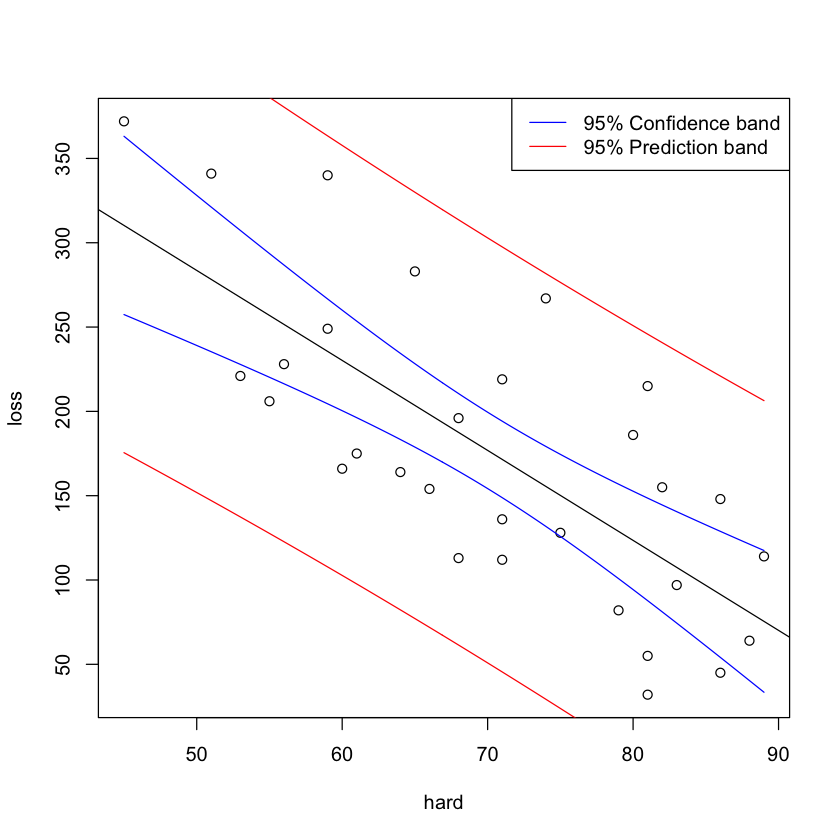

```r
x1 <- min(hard)

# range of x values in the observed sample
x2 <- max(hard)

# Vector of 200 x values equally spaced between the min and max
x <- seq(x1, x2, l=200)

# data frame with the given x values
new.tires <- data.frame( hard=x )

# Confidence and prediction intervals off of data
conf.int <- predict(loss.lm, new.tires, interval='confidence')
pred.int <- predict(loss.lm, new.tires, interval='prediction')

# create the scatter plot
plot(loss~hard)

# add the regression line
abline(loss.lm)

# Add confidence interval bounds
lines(x, conf.int[,2], col='blue')
lines(x, conf.int[,3], col='blue')

# Add prediction interval bounds
lines(x, pred.int[,2], col='red')
lines(x, pred.int[,3], col='red')

# add legend
legend('topright', lty=1, col=c('blue', 'red'), legend=c('95% Confidence band', '95% Prediction band'))
```